## Day 4: Statistics & advanced data analysis

### In-class worksheet, solutions

**June 24th, 2021**

## 1. Hypothesis testing

Ideally a hypothesis test should proceed in 4 steps:

1. Decide on an effect you are interested in, design an appropriate experiment, and pick a test statistic.
2. Frame your null hypothesis – what does your null distribution look like? Is it a one-sided or two-sided hypothesis? If necessary, calculate your null distribution.
3. Collect the data and compute the test statistic.
4. Compute p-values for your test statistic, decide if it falls above or below your threshold.

### 1.1 t-test

The most commonly used test in biology might be the t-test, which is useful for determining if there is a significant difference between your control and test cases (e.g., treated and untreated samples).

The `PlantGrowth` data set contains yields (as measured by the dried weight of plants in the `weight` column) obtained under a control and two different treatment conditions. Plot the distribution of plant `weight` measurements for each condition using `geom_violin` and formulate a hypothesis.

```r
# your R code here
```

```r
# your R code here
```

When we set `var.equal = TRUE`, we’re making a simplifying assumption that the two groups we’re comparing have equal or near equal variance. You can set `var.equal = FALSE` to remove this assumption, and R will perform Welch’s t-test instead. How does the p-value change?

The `tidyverse` also contains a function called `t_test()` for setting up this test with tidy input/output.

```r
# your R code here
```

### 1.2 p-values and false discovery rate

The p-value is the end result uniting all hypothesis tests. Built-in statistical tests in R such as `t.test()` (or `t_test()` in the tidyverse) generally calculate this value for you. However, depending on the experiment and the size of the data, we might find it easier to manually compute our own test statistics and resulting p-values.

We will use the APMS data analyzed yesterday to demonstrate this. These data have a manually computed z-score for each observed protein. This paper contains the exact equation used to calculate the `PSM_zscore` column: https://elifesciences.org/articles/58662

```r
# download the APMS data for dnai2
dnai2_apms <- read_csv("https://rachaelcox.github.io/classes/datasets/frog_heatr2_dnai2_annotated.csv") %>%
  filter(bait == "dnai2") %>%
  select(XENLA_GeneNames, matches("*PSM*"))
head(dnai2_apms)
```

```
## # A tibble: 6 x 6
##   XENLA_GeneNames                ctrl_PSMs exp_PSMs PSM_fc PSM_log2fc PSM_zscore
##   <chr>                              <dbl>    <dbl>  <dbl>      <dbl>      <dbl>
## 1 dnai2.S                                0      202 200.        7.64       14.2
## 2 loc100494633.L, loc100494633.…        80      265   3.23      1.69        9.90
## 3 dnai1.L                                0       46  46.2       5.53        6.76
## 4 loc101730961.L, dnah11.L, dna…         1       35  17.7       4.15        5.64
## 5 cps1.L, cad.L                          9       52   5.21      2.38        5.47
## 6 pc.S                                  72      133   1.81      0.853       4.16
```

To calculate p-values and create a new column containing those p-values, we will use a combination of the `mutate()` function from the tidyverse and the `pnorm()` function built into R. If we want to specify that this is a one-sided test, we need to include the argument `lower.tail = FALSE`. For visualization purposes, lets also create a new column that labels each point as either “significant” or “not significant” based on a 0.05 significance level.

```r
# your R code here
```

```r
# your R code here
```

```r
# your R code here
```

```r
# your R code here
```

Now, do the same for the `heatr2_apms` data.

```r
# download the APMS data for heatr2
heatr2_apms <- read_csv("https://rachaelcox.github.io/classes/datasets/frog_heatr2_dnai2_annotated.csv") %>%
  filter(bait == "heatr2") %>%
  select(XENLA_GeneNames, matches("*PSM*"))
head(heatr2_apms)
```

```
## # A tibble: 6 x 6
##   XENLA_GeneNames                ctrl_PSMs exp_PSMs PSM_fc PSM_log2fc PSM_zscore
##   <chr>                              <dbl>    <dbl>  <dbl>      <dbl>      <dbl>
## 1 dnaaf5.L, dnaaf5.S                     0      274 241.         7.91      16.0
## 2 gcn1.S, gcn1.L                        31       79   2.19       1.13       3.98
## 3 ipo7.L                                17       54   2.68       1.42       3.94
## 4 ipo9.L, ipo9.S                        17       49   2.43       1.28       3.49
## 5 myo5b.S, myo5c.L, myo5b.L, my…         0       10   9.64       3.27       3.05
## 6 hsph1.L, hsph1.S, hspa4.L, hs…         5       22   3.36       1.75       3.01
```

Step 1: Calculate p-values from the test statistic (in this case, the z-score).

```r
# your R code here
```

Step 2: Visualize how many results are called “significant” at a **5% false positive rate**.

```r
# your R code here
```

Step 3: Calculate the false discovery rate using the Benjamini-Hochberg method.

```r
# your R code here
```

Step 4: Visualize how many results are called “significant” at a **5% false discovery rate**.

```r
# your R code here
```

## 2. Principal Component Analysis (PCA)

The iris dataset has four measurements per observational unit (iris plant):

```r
head(iris)
```

```
##   Sepal.Length Sepal.Width Petal.Length Petal.Width Species
## 1          5.1         3.5          1.4         0.2  setosa
## 2          4.9         3.0          1.4         0.2  setosa
## 3          4.7         3.2          1.3         0.2  setosa
## 4          4.6         3.1          1.5         0.2  setosa
## 5          5.0         3.6          1.4         0.2  setosa
## 6          5.4         3.9          1.7         0.4  setosa
```

If we want to find out which characteristics are most distinguishing between iris plants, we have to make many individual plots and hope we can see distinguishing patterns:

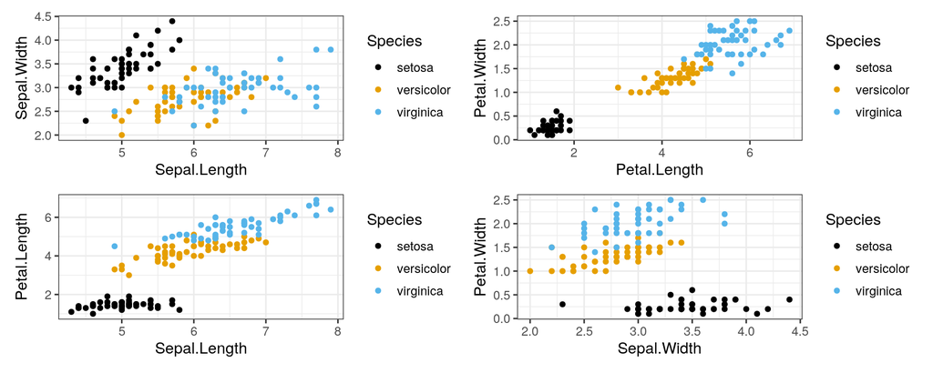

```r
p1 <- ggplot(iris, aes(x = Sepal.Length, y = Sepal.Width, color = Species)) +
  geom_point() +
  scale_color_colorblind()

p2 <- ggplot(iris, aes(x = Petal.Length, y = Petal.Width, color = Species)) +
  geom_point() +
  scale_color_colorblind()

p3 <- ggplot(iris, aes(x = Sepal.Length, y = Petal.Length, color = Species)) +
  geom_point() +
  scale_color_colorblind()

p4 <- ggplot(iris, aes(x = Sepal.Width, y = Petal.Width, color = Species)) +
  geom_point() +
  scale_color_colorblind()

p1 + p2 + p3 + p4 + plot_layout(ncol = 2) # arrange in a grid
```

In this particular case, it seems that petal length and petal width are most distinct for the three species. Principal Components Analysis (PCA) allows us to systematically discover such patterns, and it works also when there are many more variables than just four.

The basic steps in PCA are to (i) prepare a data frame that holds only the numerical columns of interest, (ii) scale the data to 0 mean and unit variance, and (iii) do the PCA with the function prcomp():

```r
pca <- iris %>%
  select(-Species) %>%  # remove Species column
  scale() %>%           # scale to 0 mean and unit variance
  prcomp()              # perform `pca`

# now display the results from the PCA analysis
pca
```

```
## Standard deviations (1, .., p=4):
## [1] 1.7083611 0.9560494 0.3830886 0.1439265
##
## Rotation (n x k) = (4 x 4):
##                     PC1         PC2        PC3        PC4
## Sepal.Length  0.5210659 -0.37741762  0.7195664  0.2612863
## Sepal.Width  -0.2693474 -0.92329566 -0.2443818 -0.1235096
## Petal.Length  0.5804131 -0.02449161 -0.1421264 -0.8014492
## Petal.Width   0.5648565 -0.06694199 -0.6342727  0.5235971
```

The main output for PCA are the standard deviations and rotation matrix. However, we’re most interested in the principal component (PC#) data, available as `pca$x`:

```r
head(pca$x)
```

```
##            PC1        PC2         PC3          PC4
## [1,] -2.257141 -0.4784238  0.12727962  0.024087508
## [2,] -2.074013  0.6718827  0.23382552  0.102662845
## [3,] -2.356335  0.3407664 -0.04405390  0.028282305
## [4,] -2.291707  0.5953999 -0.09098530 -0.065735340
## [5,] -2.381863 -0.6446757 -0.01568565 -0.035802870
## [6,] -2.068701 -1.4842053 -0.02687825  0.006586116
```

But since we removed the categorical `Species` column in order to scale the matrix, we have lost that information. First, we need to add it back onto the data frame using the `data.frame()` function we discussed in day 1:

```r
pca_data <- data.frame(pca$x, Species = iris$Species)
head(pca_data)
```

```
##         PC1        PC2         PC3          PC4 Species
## 1 -2.257141 -0.4784238  0.12727962  0.024087508  setosa
## 2 -2.074013  0.6718827  0.23382552  0.102662845  setosa
## 3 -2.356335  0.3407664 -0.04405390  0.028282305  setosa
## 4 -2.291707  0.5953999 -0.09098530 -0.065735340  setosa
## 5 -2.381863 -0.6446757 -0.01568565 -0.035802870  setosa
## 6 -2.068701 -1.4842053 -0.02687825  0.006586116  setosa
```

And now we can plot as usual:

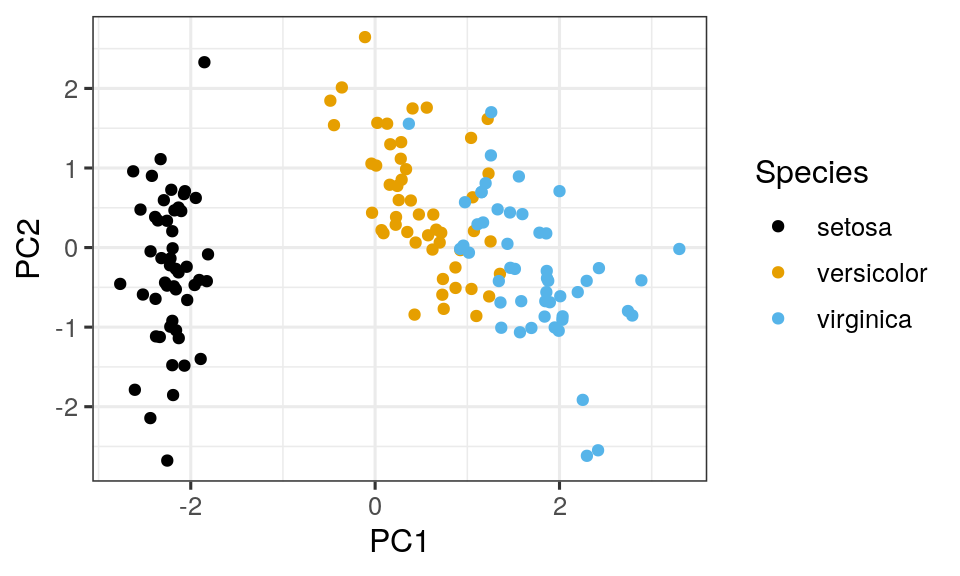

```r
ggplot(pca_data, aes(x = PC1, y = PC2,
                     color = Species)) +
  geom_point() +
  scale_color_colorblind()
```

In the above plot, the species are much better separated. Now, if we look at the rotation matrix, we can learn which of the 4 flower measurements for each species most contributes to the variation between species (i.e., how much each variable contributes to each principle component).

```r
head(pca$rotation)
```

```
##                     PC1         PC2        PC3        PC4
## Sepal.Length  0.5210659 -0.37741762  0.7195664  0.2612863
## Sepal.Width  -0.2693474 -0.92329566 -0.2443818 -0.1235096
## Petal.Length  0.5804131 -0.02449161 -0.1421264 -0.8014492
## Petal.Width   0.5648565 -0.06694199 -0.6342727  0.5235971
```

It’s most useful to plot this information using arrows, which let us visualize the magnitude of contribution to each PC:

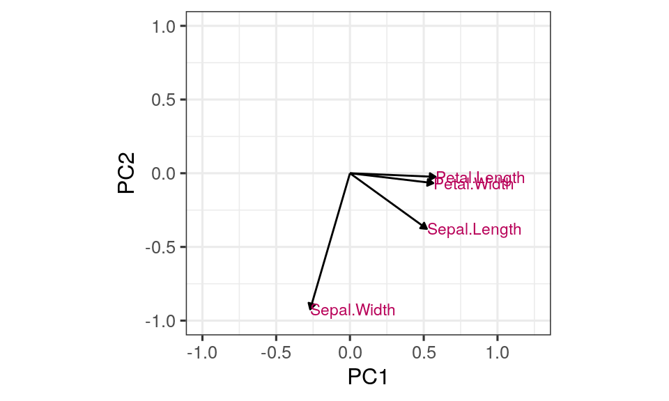

```r
# capture the rotation matrix in a data frame
rotation_data <- data.frame(pca$rotation,
                            variable = row.names(pca$rotation))

# define a nice arrow style
arrow_style <- arrow(length = unit(0.05, "inches"),
                     type = "closed")

# now plot, using geom_segment() for arrows and geom_text() for labels
ggplot(rotation_data) +
  geom_segment(aes(xend = PC1, yend = PC2),
               x = 0, y = 0, arrow = arrow_style) +
  geom_text(aes(x = PC1, y = PC2,
                label = variable),
            hjust = 0,
            size = 3,
            color = "#b80058") +
  xlim(-1., 1.25) +
  ylim(-1., 1.) +
  coord_fixed() # fix aspect ratio to 1:1
```

We can now see clearly that Petal.Length, Petal.Width, and Sepal.Length all contribute to PC1, and Sepal.Width dominates PC2.

Finally, we want to look at the percent variance explained. The prcomp() function gives us standard deviations (stored in pca$sdev). To convert them into percent variance explained, we square them and then divide by the sum over all squared standard deviations:

```r
percent <- 100*pca$sdev^2 / sum(pca$sdev^2)
percent
```

```
## [1] 72.9624454 22.8507618  3.6689219  0.5178709
```

The first component explains 73% of the variance, the second 23%, the third 4% and the last 0.5%. We can visualize these results nicely in a bar plot:

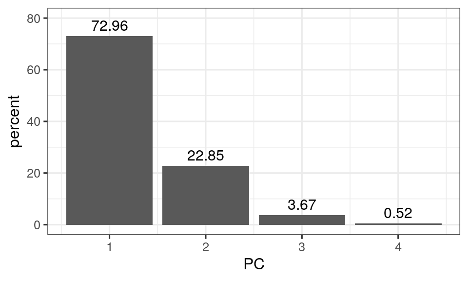

```r
perc_data <- data.frame(percent = percent, PC = 1:length(percent))

ggplot(perc_data, aes(x = PC, y = percent)) +
  geom_col() +
  geom_text(aes(label = round(percent, 2)), size = 4, vjust = -0.5) +
  ylim(0, 80)
```

### Try it yourself

Now do it yourself using the `wine_features` data set. The data set wine_features contains 6497 rows describing various chemical attributes of red and white wine (indicated by the `type` column) and each wine’s relative quality (indicated by the `quality` column) on a scale of 3 to 9 as graded by experts performing a blind taste test. Chemical attributes recorded for each wine include `fixed_acidity`, `volatile_acidity`, `citric_acid`, `residual_sugar`, `chlorides`, `free_sulfur_dioxide`, `total_sulfur_dioxide`, `density`, `pH`, `sulphates`, `alcohol`.

```r
wine_features <-
  read_csv("https://rachaelcox.github.io/classes/datasets/wine_features.csv") %>%
  mutate(type = as.factor(type)) %>%
  select(-quality_grade, -alcohol_grade, -acidity_grade)
```

Step 1: Remove categorical variable `type` from the `wine_features` data frame, scale the data around 0, then use `prcomp()` to perform PCA. Reattach `type` to the transformed PC values made available `pca$x`. **Hint:** Refer to example above for code.

```r
# your R code here
```

Step 2: Make a scatter plot of PC2 vs PC1, coloring by `type`.

```r
# your R code here
```

Step 3: Convert the rotation matrix to a data frame, and then plot the rotation data using arrows with `geom_segment()` and `geom_text()`. **Hint:** Refer to example above for code.

```r
# your R code here
```

Step 4: Evaluate how much of the variance is explained by PC1 and PC2.

```r
# your R code here
```